# LAB2

1/30/2019

## Outline

- R package `igraph`
  - Paths
    - Paths, distances and diameter
    - Components
    - Transitivity and reciprocity
    - Max-flow and min-cut
  - Communities
    - Pre-defined clusters
    - Different algorithms
  - Visualization
    - Color the paths
    - Plotting clusters
    - Plotting dendrograms
    - Mark groups

## `igraph`

- Official website (handbook): http://igraph.org/r/
- Book: https://sites.fas.harvard.edu/~airoldi/pub/books/BookDraft-CsardiNepuszAiroldi2016.pdf

## Preparation

```r
library(igraph)
library(igraphdata)
data(USairports)
data(karate)
```

```r
?USairports
?karate
```

## Preprocess

```r
USairports
```

```
## IGRAPH bf6202d DN-- 755 23473 -- US airports
## + attr: name (g/c), name (v/c), City (v/c), Position (v/c),
## | Carrier (e/c), Departures (e/n), Seats (e/n), Passengers (e/n),
## | Aircraft (e/n), Distance (e/n)
## + edges from bf6202d (vertex names):
##  [1] BGR->JFK BGR->JFK BOS->EWR ANC->JFK JFK->ANC LAS->LAX MIA->JFK
##  [8] EWR->ANC BJC->MIA MIA->BJC TEB->ANC JFK->LAX LAX->JFK LAX->SFO
## [15] AEX->LAS BFI->SBA ELM->PIT GEG->SUN ICT->PBI LAS->LAX LAS->PBI
## [22] LAS->SFO LAX->LAS PBI->AEX PBI->ICT PIT->VCT SFO->LAX VCT->DWH
## [29] IAD->JFK ABE->CLT ABE->HPN AGS->CLT AGS->CLT AVL->CLT AVL->CLT
## [36] AVP->CLT AVP->PHL BDL->CLT BHM->CLT BHM->CLT BNA->CLT BNA->CLT
## + ... omitted several edges
```

```r
#should have no self-loop
sum(which_loop(USairports))
```

```
## [1] 53
```

```r
USairports <- simplify(USairports, remove.loops = TRUE, remove.multiple = FALSE)
sum(which_loop(USairports))
```

```
## [1] 0
```

```r
#different carrier and aircraft types leading to multiple graphs
USairports[["RDU","JFK",edges=TRUE]][[1]][[1:5]]
```

```
## + 5/23420 edges from fd20447 (vertex names):
##       tail head tid hid                      Carrier Departures Seats
## 22271  RDU  JFK  74   4     Chautauqua Airlines Inc.         27  1350
## 20487  RDU  JFK  74   4 American Eagle Airlines Inc.         48  2112
## 20486  RDU  JFK  74   4 American Eagle Airlines Inc.         57  2109
## 14914  RDU  JFK  74   4                  Comair Inc.          1    76
## 14913  RDU  JFK  74   4                  Comair Inc.          5   250
##       Passengers Aircraft Distance
## 22271       1118      675      426
## 20487       1881      676      426
## 20486       1833      674      426
## 14914         68      638      426
## 14913        209      629      426
```

```r
#simplify
air <- simplify(USairports, edge.attr.comb =list(Departures = "sum", Seats = "sum", Passengers = "sum",Distance="mean", "ignore"))
air
```

```
## IGRAPH ad812c4 DN-- 755 8228 -- US airports
## + attr: name (g/c), name (v/c), City (v/c), Position (v/c),
## | Departures (e/n), Seats (e/n), Passengers (e/n), Distance (e/n)
## + edges from ad812c4 (vertex names):
##  [1] BGR->BOS BGR->JFK BGR->MIA BGR->EWR BGR->DCA BGR->DTW BGR->LGA
##  [8] BGR->PHL BGR->PIE BGR->SFB BOS->BGR BOS->JFK BOS->LAS BOS->MIA
## [15] BOS->EWR BOS->LAX BOS->PBI BOS->PIT BOS->SFO BOS->IAD BOS->BDL
## [22] BOS->BUF BOS->BWI BOS->CAK BOS->CLE BOS->CLT BOS->CMH BOS->CVG
## [29] BOS->DCA BOS->DTW BOS->GSO BOS->IND BOS->LGA BOS->MDT BOS->MKE
## [36] BOS->MSP BOS->MSY BOS->MYR BOS->ORF BOS->PHF BOS->PHL BOS->RDU
## [43] BOS->RIC BOS->SRQ BOS->STL BOS->SYR BOS->ALB BOS->PVD BOS->ROC
## + ... omitted several edges
```

```r
air[["RDU","JFK",edges=TRUE]]
```

```
## [[1]]
## + 1/8228 edge from ad812c4 (vertex names):
## [1] RDU->JFK
```

## Paths

## Paths, distances and diameter

## Select specific paths

Select specific paths

```r
#select length 1 path
air[[from="RDU",to="BOS",edges=TRUE]]
```

```
## [[1]]
## + 1/8228 edge from ad812c4 (vertex names):
## [1] RDU->BOS
```

```r
# select >=1 paths
flight_rdu_bos=V(air)["RDU","JFK","BOS"]
E(air,path=flight_rdu_bos)
```

```
## + 2/8228 edges from ad812c4 (vertex names):
## [1] RDU->JFK JFK->BOS
```

```r
#another way
E(air)["RDU"%->%"JFK","JFK"%->%"BOS"]
```

```
## + 2/8228 edges from ad812c4 (vertex names):
## [1] RDU->JFK JFK->BOS
```

## Shortest paths

Many paths between edges. Direct flight or multiple steps.

Length of path: number of edges included in a path

`shortest_paths`: only one of the shortest paths

`all_shortest_paths`: all the shortest paths; `nrgeo` is the resultant vector of values from Djikstra's algorithm which is used to find the shortest paths.

```r
#arkansas airport-XNA
shortest_paths(air,from="RDU",to = "XNA",weights = E(air)$Distance)$vpath
```

```
## [[1]]
## + 3/755 vertices, named, from ad812c4:
## [1] RDU CLT XNA
```

```r
shortest_paths(air,from="RDU",to = "XNA",weights = NA)$vpath #one of the shortest path
```

```
## [[1]]
## + 3/755 vertices, named, from ad812c4:
## [1] RDU LAS XNA
```

```r
shortest_paths(air,from="RDU",to = "XNA",mode = "in",weights = NA)$vpath #to
```

```
## [[1]]
## + 3/755 vertices, named, from ad812c4:
## [1] RDU BOS XNA
```

```r
shortest_paths(air,from="RDU",to = "XNA",mode = "out",weights = NA)$vpath #from
```

```
## [[1]]
## + 3/755 vertices, named, from ad812c4:
## [1] RDU LAS XNA
```

```r
shortest_paths(air,from="RDU",to = "XNA",mode = "all",weights = NA)$vpath #undirected
```

```
## [[1]]
## + 3/755 vertices, named, from ad812c4:
## [1] RDU BOS XNA
```

```r
all_shortest_paths(air,from="RDU",to = "XNA",weight=NA)$res
```

```
## [[1]]
## + 3/755 vertices, named, from ad812c4:
## [1] RDU MEM XNA
##
## [[2]]
## + 3/755 vertices, named, from ad812c4:
## [1] RDU DFW XNA
##
## [[3]]
## + 3/755 vertices, named, from ad812c4:
## [1] RDU DEN XNA
##
## [[4]]
## + 3/755 vertices, named, from ad812c4:
## [1] RDU ATL XNA
##
## [[5]]
## + 3/755 vertices, named, from ad812c4:
## [1] RDU ORD XNA
##
## [[6]]
## + 3/755 vertices, named, from ad812c4:
## [1] RDU IAH XNA
##
## [[7]]
## + 3/755 vertices, named, from ad812c4:
## [1] RDU MSP XNA
##
## [[8]]
## + 3/755 vertices, named, from ad812c4:
## [1] RDU LGA XNA
##
## [[9]]
## + 3/755 vertices, named, from ad812c4:
## [1] RDU DTW XNA
##
## [[10]]
## + 3/755 vertices, named, from ad812c4:
## [1] RDU CVG XNA
##
## [[11]]
## + 3/755 vertices, named, from ad812c4:
## [1] RDU CLT XNA
##
## [[12]]
## + 3/755 vertices, named, from ad812c4:
## [1] RDU EWR XNA
##
## [[13]]
## + 3/755 vertices, named, from ad812c4:
## [1] RDU LAS XNA
```

```r
all_shortest_paths(air,from="RDU",to = "XNA",weights = E(air)$Distance)$res
```

```
## [[1]]
## + 3/755 vertices, named, from ad812c4:
## [1] RDU CLT XNA
```

## Color certain paths:

Color the path from `Actor 33` to `Mr Hi` and set the width for the path.

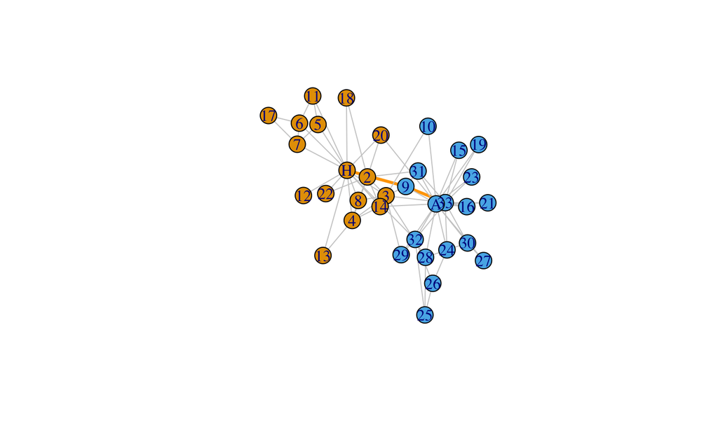

```r
path_vk=shortest_paths(karate,from="Actor 33", to="Mr Hi")$vpath[[1]]
ecol=rep("gray80",ecount(karate))
ecol[E(karate,path = path_vk)]="orange"
ew=rep(1,ecount(karate))
ew[E(karate,path = path_vk)]=3
plot(karate,edge.color=ecol,edge.width=ew)
```

## distance

Distance: length of shortest path

`distance_table`: The frequency of shortest path length between each pair of vertices.

```r
distance_table(air)
```

```
## $res
## [1]   8228  94912 166335 163830  86263  15328   2793    291     27
##
## $unconnected
## [1] 31263
```

```r
# unconnected: the number of pairs for which the first vertex is not reachable from the second
```

`distances`

```r
distances(air,"RDU","XNA",weights = NA) # not consider the weight
```

```
##     XNA
## RDU   2
```

```r
distances(air,"RDU","XNA",weights =  E(air)$Distance) # specify the weight
```

```
##     XNA
## RDU 884
```

```r
# how the function `distances` works
(shortest_paths(air,from="RDU",to = "XNA",weights = E(air)$Distance)$vpath[[1]])
```

```
## + 3/755 vertices, named, from ad812c4:
## [1] RDU CLT XNA
```

```r
E(air)["RDU"%->%"CLT","CLT"%->%"XNA"]$Distance%>%sum()
```

```
## [1] 884
```

```r
#can return a distance matrix
distances(air,c("BOS","JFK","RDU","XNA"),c("BOS","JFK","RDU","XNA"),weights = E(air)$Distance,mode = "all") #undirected
```

```
##      BOS  JFK RDU  XNA
## BOS    0  187 612 1312
## JFK  187    0 426 1150
## RDU  612  426   0  884
## XNA 1312 1150 884    0
```

```r
distances(air,c("BOS","JFK","RDU","XNA"),c("BOS","JFK","RDU","XNA"),weights = E(air)$Distance,mode = "in") #focus on to
```

```
##      BOS  JFK RDU  XNA
## BOS    0  187 612 1312
## JFK  187    0 426 1150
## RDU  612  426   0  884
## XNA 1313 1150 884    0
```

```r
distances(air,c("BOS","JFK","RDU","XNA"),c("BOS","JFK","RDU","XNA"),weights = E(air)$Distance,mode = "out") #focus on from # tranpose of mode "in"
```

```
##      BOS  JFK RDU  XNA
## BOS    0  187 612 1313
## JFK  187    0 426 1150
## RDU  612  426   0  884
## XNA 1312 1150 884    0
```

`mean_distance`: average path length in a graph, by calculating the shortest paths between **all** pairs of vertices (both ways for directed graphs). **does not consider edge weights currently** and uses a breadth-first search.

```r
# connected=TRUE
mean_distance(air,directed = TRUE)
```

```
## [1] 3.52743
```

```r
# How the function works
freq=distance_table(air)$res/sum(distance_table(air)$res)
sum(freq*1:9)
```

```
## [1] 3.52743
```

```r
#connected=FALSE
mean_distance(air,directed = TRUE,unconnected = FALSE)
```

```
## [1] 44.79658
```

```r
#How the function works
freq=c(distance_table(air)$res,distance_table(air)$unconnected)/sum(c(distance_table(air)$res,distance_table(air)$unconnected))
sum(freq*c(1:9,vcount(air)))
```

```
## [1] 44.79658
```

## Diameter

diameter: The largest distance of a graph. In the special case when some vertices are not reachable via a path from some others, returns the longest finite distance.

```r
diameter(air)
```

```
## [1] 9
```

```r
diameter(air,weights = E(air)$Distance)
```

```
## [1] 11257
```

```r
diameter(air,directed = FALSE)
```

```
## [1] 8
```

```r
#can also specify the unconnected=TRUE/FALSE
```

## Get the nodes and edges of the airports in the longest path

```r
#get the nodes
get_diameter(air,weights = E(air)$Distance)
```

```
## + 9/755 vertices, named, from ad812c4:
## [1] VNY ORL OPF SDF STL SFO GUM SPN TIQ
```

```r
dia_v=get_diameter(air,weights = E(air)$Distance)
# information of nodes
dia_v[[]]
```

```
## + 9/755 vertices, named, from ad812c4:
##     name              City         Position
## 717  VNY      Van Nuys, CA N341235 W1182924
## 713  ORL       Orlando, FL N283244 W0811959
## 712  OPF         Miami, FL N255425 W0801642
## 78   SDF    Louisville, KY N381028 W0854410
## 80   STL     St. Louis, MO N384452 W0902136
## 18   SFO San Francisco, CA N373708 W1222230
## 178  GUM          Guam, TT N132900 E1444746
## 180  SPN        Saipan, TT N150708 E1454346
## 181  TIQ        Tinian, TT N145949 E1453705
```

```r
# edges
E(air,path = dia_v)
```

```
## + 8/8228 edges from ad812c4 (vertex names):
## [1] VNY->ORL ORL->OPF OPF->SDF SDF->STL STL->SFO SFO->GUM GUM->SPN SPN->TIQ
```

```r
# info of edges
dia_e=E(air,path = dia_v)
dia_e[[]]
```

```
## + 8/8228 edges from ad812c4 (vertex names):
##      tail head tid hid Departures Seats Passengers Distance
## 8184  VNY  ORL 717 713          1    12          4     2218
## 8178  ORL  OPF 713 712          1    12          4      193
## 8177  OPF  SDF 712  78          1    10          2      904
## 2696  SDF  STL  78  80         60  8220       5837      254
## 2735  STL  SFO  80  18         31  3852       2820     1736
## 804   SFO  GUM  18 178         26 10675       9951     5812
## 5350  GUM  SPN 178 180        164  7544       4554      129
## 5356  SPN  TIQ 180 181        283  1698       1576       11
```

```r
## delete the flight with passengers <= 10 then recalculate the diameter

air_filt=delete_edges(air,E(air)[Passengers<=10])
get_diameter(air_filt,weights = E(air_filt)$Distance)
```

```
## + 8/755 vertices, named, from 1dc4ba9:
## [1] TIQ SPN GUM HNL LAX OKC NYL JQF
```

## Color the paths along the diameter

First step is to select the edges along the path.

Then just change the edge attribute.

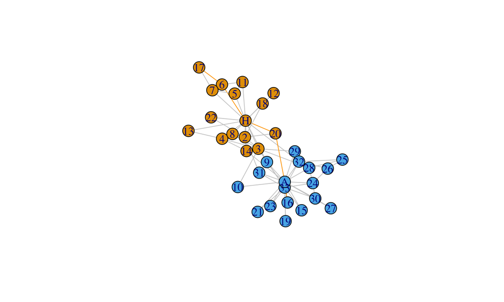

```r
dia_vk=get_diameter(karate,directed = FALSE)
ecol=rep("gray80",ecount(karate))
ecol[E(karate,path = dia_vk)]="orange"
plot(karate,edge.color=ecol)
```

## Components

## Components

For an undirected graph,

Connected: if there is a path from any vertex to any other.

Unconnected: if not connected. An unconnected graph has multiple components.

Components: a maximal induced subgraph that is connected.

```r
is_connected(air)
```

```
## [1] FALSE
```

```r
count_components(air)
```

```
## [1] 6
```

```r
#no:number of components
names(igraph::components(air))
```

```
## [1] "membership" "csize"      "no"
```

```r
igraph::components(air)$csize
```

```
## [1] 745   2   2   3   2   1
```

```r
igraph::components(air)$membership[igraph::components(air)$membership==6]
```

```
## DET
##   6
```

```r
# check whether RDU is in the largest component
subcomponent(air,"RDU") #not bad
```

```
## + 745/755 vertices, named, from ad812c4:
##   [1] RDU BOS JFK LAS MIA EWR TEB PIT IAD BDL BNA BTR BWI CLE CLT CMH CVG
##  [18] DCA DTW GPT GSO ILM IND LEX LGA MDT MKE MSP PHL STL SYR TYS MHT PVD
##  [35] FLL MCO TPA IAH ORD CID MCI MSN SBN ATL DEN DFW MDW PHX RSW TUS ACY
##  [52] MEM SJU UTM SWO DAL ECP EVV LAN PIA FRG ISO BGR LAX PBI SFO BUF CAK
##  [69] MSY MYR ORF PHF RIC SRQ XNA ALB ROC SCE BHB PBG PQI AUS PDX SAN SEA
##  [86] SLC JAX STT SJC LGB PTK PGD IAG ACK LEB MVY PVC BMG AUG HYA RKD RUT
## [103] SLK ANC ABE AVP PWM SAV BTV SWF LWB CKB OKC HOU SAT SMF SNA BUR OAK
## [120] EGE BQN PSE FAR FWA FOE AEX GEG ICT BHM HPN LIT SDF MAF SHV MLI OMA
## [137] SGF TUL ABQ DSM GRR AMA LBB BOI HNL OGG ONT RNO COS ELP FAT GJT MFE
## [154] PSP BLI EUG ATW BIL BZN DLH FSD GRB GTF IDA MOT MSO BIS GFK RAP AZA
## + ... omitted several vertices
```

## strongly connected and weakly connected

For a directed network,

weakly connected: its corresponding undirected network that ignored edge directions, is connected

strongly connected: if and only if it has a directed path from each vertex to all other vertices.

```r
is_connected(air,mode = "weak")
```

```
## [1] FALSE
```

```r
is_connected(air,mode = "strong")
```

```
## [1] FALSE
```

```r
count_components(air,mode = "strong")
```

```
## [1] 30
```

```r
igraph::components(air,mode = "strong")$membership%>%table()
```

```
## .
##   1   2   3   4   5   6   7   8   9  10  11  12  13  14  15  16  17  18
##   1   1   1   1   1   1   1   1   1   1   2   1   2   1   1   2   1   1
##  19  20  21  22  23  24  25  26  27  28  29  30
##   1   1   1   1   1   1 723   1   1   1   1   1
```

```r
# check whether RDU is in the largest component
"RDU"%in%(igraph::components(air,mode = "strong")$membership[igraph::components(air,mode = "strong")$membership==25]%>%names()) # not bad
```

```
## [1] TRUE
```

## Transitivity and reciprocity

Network and node properties

## Reciprocity

The proportion of reciprocated ties for a directed network

```r
#number of reciprocity edges divided by number of edges
reciprocity(air)
```

```
## [1] 0.8762761
```

```r
2*dyad_census(air)$mut/ecount(air)
```

```
## [1] 0.8762761
```

```r
# number of mutual pairs divided by number of connected pairs
reciprocity(air,mode = "ratio")
```

```
## [1] 0.7797967
```

```r
dyad_census(air)$mut/(dyad_census(air)$mut+dyad_census(air)$asym)
```

```
## [1] 0.7797967
```

```r
#number of pairs
dyad_census(air)
```

```
## $mut
## [1] 3605
##
## $asym
## [1] 1018
##
## $null
## [1] 280012
```

## transitivity

global: ratio of triangles to connected triples.

local: ratio of triangles to connected triples each vertex is part of.

```r
transitivity(air,type = "global")
```

```
## [1] 0.3384609
```

```r
transitivity(air,type = "local")[1:5]
```

```
## [1] 0.16842105 0.09683141 0.02803235 0.11144883 0.05888073
```

```r
transitivity(air,vids = c("RDU","JFK"),type = "local") # specify multiple vertices
```

```
## [1] 0.4803279 0.3859649
```

```r
#corresponds to different types of triples
triad_census(air)
```

```
##  [1] 68169544   712579  2380343     1445     1289     2465    15322
##  [8]    19171       91       39   114868      202      376      558
## [15]     6422    18671
```

```r
?triad_census
```

## maximum flows and minimum cuts

max flow How many passengers the US airport network can transport from a given airport to another one.

```r
E(air)[["BOS"%->%"JFK"]]
```

```
## + 1/8228 edge from ad812c4 (vertex names):
##    tail head tid hid Departures Seats Passengers Distance
## 12  BOS  JFK   2   4        491 39403      31426      187
```

```r
# use seat to present the capacity.
max_flow(air,"BOS","JFK",capacity = E(air)$Seats)$value
```

```
## [1] 1177758
```

```r
#capacity is for max_flow() function as default
E(air)$capacity=E(air)$Seats
max_flow(air,"BOS","JFK")$value
```

```
## [1] 1177758
```

## maximum flows and minimum cuts

min cut: the minimum **number of edges**, that disconnect a destination vertex from a departure vertex. In a **weighted** network with edge capacities the minimum cut calculates the **total capacity** needed to disconnect the vertex pair.

```r
E(air)[["BOS"%->%"JFK"]]
```

```
## + 1/8228 edge from ad812c4 (vertex names):
##    tail head tid hid Departures Seats Passengers Distance capacity
## 12  BOS  JFK   2   4        491 39403      31426      187    39403
```

```r
# use seat to present the capacity.
min_cut(air,"BOS","JFK",capacity = E(air)$Seats)
```

```
## [1] 1177758
```

```r
#capacity is for max_flow() function as default
E(air)$capacity=E(air)$Seats
min_cut(air,"BOS","JFK")
```

```
## [1] 1177758
```

## maximum flows and minimum cuts

max-flow min-cut theorem: the minimum cut in a graph from a source vertex to a target vertex always **equals** the maximum flow between the same vertices.

```r
min_cut(air,"BOS","JFK",capacity = E(air)$Seats)
```

```
## [1] 1177758
```

```r
max_flow(air,"BOS","JFK",capacity = E(air)$Seats)$value
```

```
## [1] 1177758
```

## Community

## Make clusters

You can speicfy the cluster as you want.

```r
data("karate")

#ground truth
V(karate)$Faction
```

```
##  [1] 1 1 1 1 1 1 1 1 2 2 1 1 1 1 2 2 1 1 2 1 2 1 2 2 2 2 2 2 2 2 2 2 2 2
```

```r
ground_truth=make_clusters(karate,V(karate)$Faction)
ground_truth
```

```
## IGRAPH clustering unknown, groups: 2, mod: 0.37
## + groups:
##   $`1`
##    [1]  1  2  3  4  5  6  7  8 11 12 13 14 17 18 20 22
##
##   $`2`
##    [1]  9 10 15 16 19 21 23 24 25 26 27 28 29 30 31 32 33 34
##
```

```r
#cluster by the distance
dist_memb=karate %>%
distances(v = c("John A", "Mr Hi")) %>%
  apply(2, which.min) %>%
make_clusters(graph = karate)
```

## Community detection

Different algorithm for community detection (clustering)

## Girvan-Newman algorithm

Girvan-Newman algorithm (edge betweenness method): the number of shortest paths passing through an intra-community edge should be low while inter-community edges are likely to act as bottlenecks that participate in many shortest paths between vertices of different communities.

```
## IGRAPH clustering edge betweenness, groups: 6, mod: 0.35
## + groups:
##   $`1`
##   [1] "Mr Hi"    "Actor 2"  "Actor 4"  "Actor 8"  "Actor 12" "Actor 13"
##   [7] "Actor 18" "Actor 20" "Actor 22"
##
##   $`2`
##   [1] "Actor 3"  "Actor 10" "Actor 14" "Actor 29"
##
##   $`3`
##   [1] "Actor 5"  "Actor 6"  "Actor 7"  "Actor 11" "Actor 17"
##
##   + ... omitted several groups/vertices
```

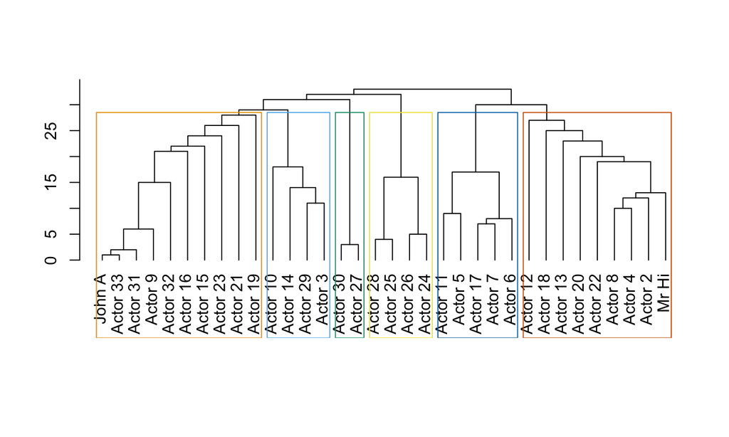

```
##    Mr Hi  Actor 2  Actor 3  Actor 4  Actor 5  Actor 6  Actor 7  Actor 8
##        1        1        2        1        3        3        3        1
##  Actor 9 Actor 10 Actor 11 Actor 12 Actor 13 Actor 14 Actor 15 Actor 16
##        4        2        3        1        1        2        4        4
## Actor 17 Actor 18 Actor 19 Actor 20 Actor 21 Actor 22 Actor 23 Actor 24
##        3        1        4        1        4        1        4        5
## Actor 25 Actor 26 Actor 27 Actor 28 Actor 29 Actor 30 Actor 31 Actor 32
##        5        5        6        5        2        6        4        4
## Actor 33   John A
##        4        4
```

```
##  [1] 2 2 1 2 2 2 2 2 1 1 2 2 2 1 1 1 2 2 1 2 1 2 1 1 1 1 1 1 1 1 1 1 1 1
```

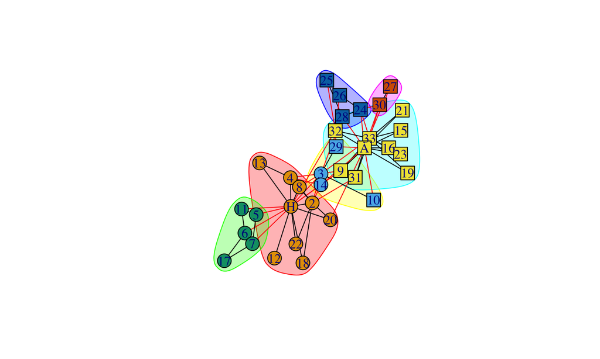

## Exact modularity maximization

Exact modularity maximization: optimization problem to maximum the modularity

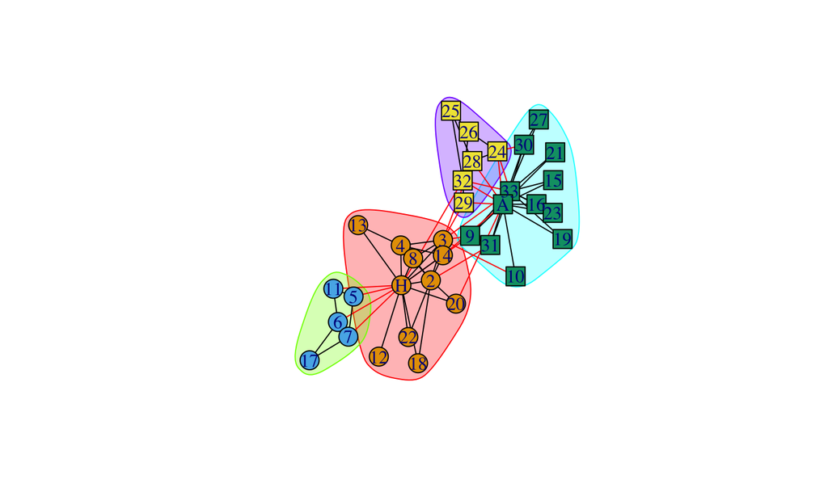

```r
optimal=cluster_optimal(karate)
set.seed(1)
plot(optimal,karate)
optimal_lg=cluster_fast_greedy(karate)
set.seed(1)
plot(optimal,karate)
```

## Leading eigenvector

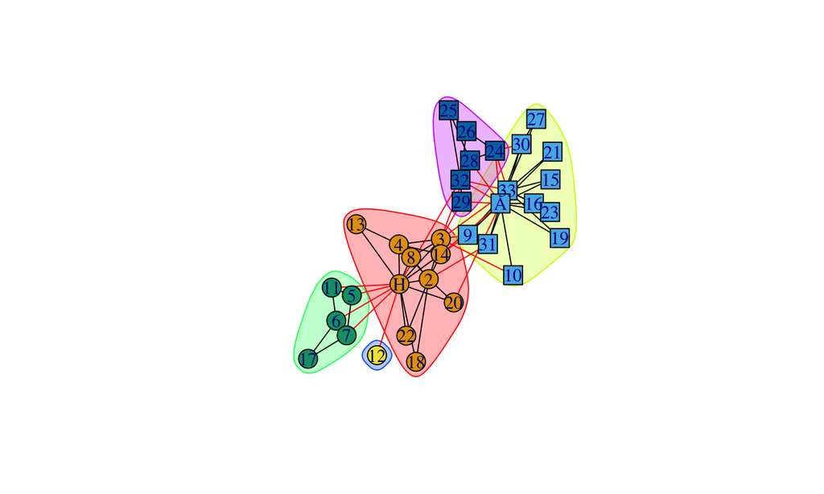

```r
eigen=cluster_leading_eigen(karate)
set.seed(1)
plot(eigen,karate)
```

```r
clusters <- cluster_leading_eigen(karate, steps = 1) #at most two cluster
```

## Label propagation algorithm:

The algorithm terminates when it holds for each node that it belongs to a community to which a maximum number of its neighbors also belong.

`fixed`: TRUE-label will not change. `initial`: initial point.

```r
#non-negative values: different labels; negative values: no labels
initial=rep(-1,vcount(karate))
fixed=rep(FALSE,vcount(karate))
#need to have names
names(initial)=names(fixed)=V(karate)$name
initial['Mr Hi']=1
initial['John A']=2
fixed['Mr Hi']=fixed['John A']=TRUE
lab=cluster_label_prop(karate,initial = initial,fixed = fixed)
set.seed(1)
plot(lab,karate)
```

[output not shown]

```r
set.seed(1)
plot(ground_truth,karate)
```

[output not shown]

## Other algorithms:

`cluster_spinglass`

…

## Visualization

## Visulization

- color the paths
- plotting clusters
- plotting dendrograms
- marked several grouping vertices

`plot` support `igraph` and other igraph objects such as `vertexclustering`, `vertexdendrogram`, …

## Plotting clusters

`plot(vertexdendrogram,igraph)`

```r
set.seed(1)
plot(ground_truth,karate)
```

[output not shown]

## Plotting dendrograms

`plot_dendrogram(vertexdendrogram)`

Not flexible enough. Try `ggdendrogram()` in `ggplot2` package.

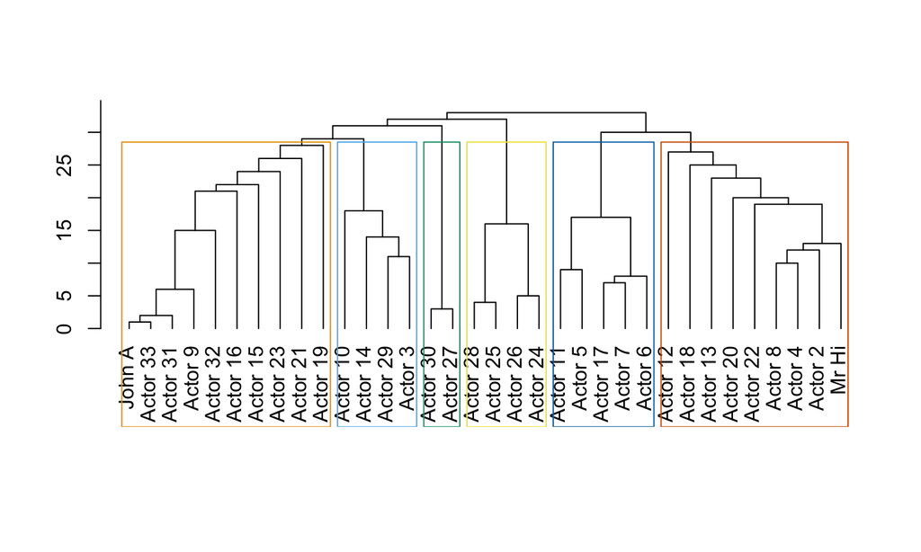

```r
set.seed(1)
plot_dendrogram(dendrogram)
```

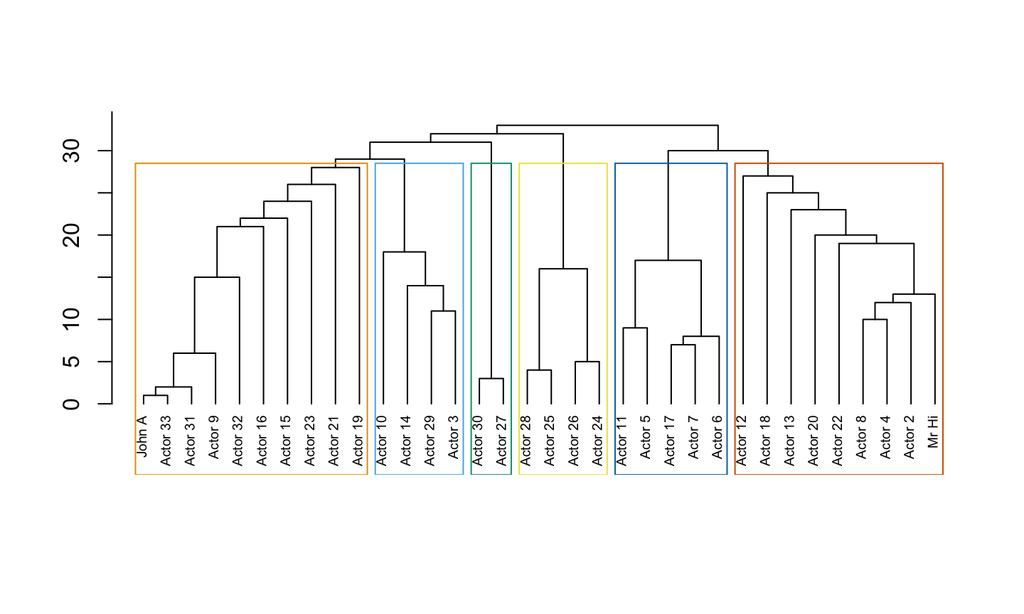

```r
#labels at the same height: hang=-1
#cex: size of labels
plot_dendrogram(dendrogram,hang = -1, cex = 0.6)
```

## marked groups

`plot`:

- `mark.group`: list
- `mark.col`: vector
- `mark.border`: vector
- `mark.shape`: vector (smoothness of the border, range from -1 to 1)
- `mark.expand`: vector (size of the border)

```r
ls=list(`1`=ground_truth[[1]],`2`=ground_truth[[2]])
ls
```

```
## $`1`
##  [1]  1  2  3  4  5  6  7  8 11 12 13 14 17 18 20 22
##
## $`2`
##  [1]  9 10 15 16 19 21 23 24 25 26 27 28 29 30 31 32 33 34
```

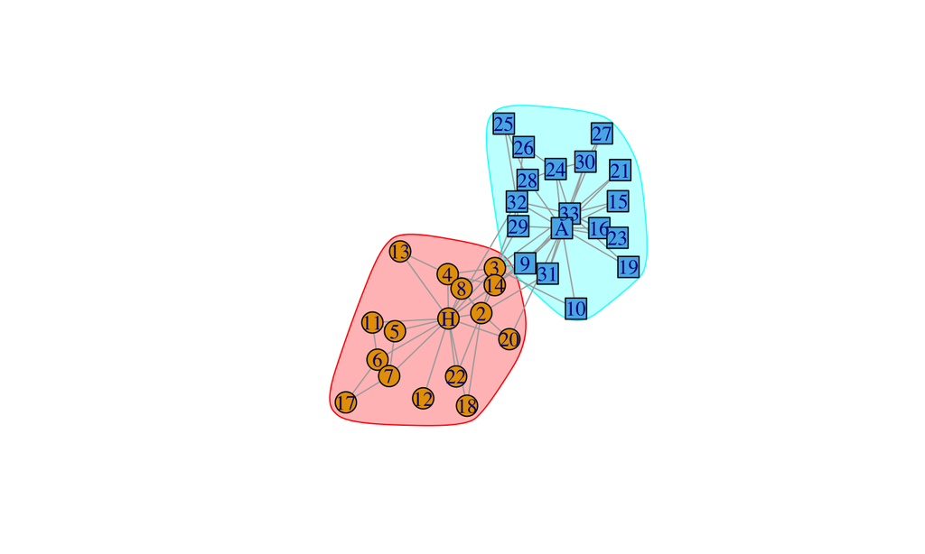

```r
# other pars can be set as default
set.seed(1)
plot(karate,mark.groups = ls)
```

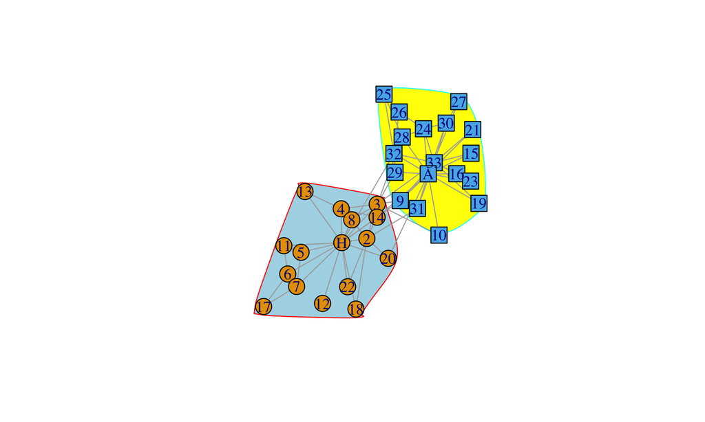

```r
set.seed(1)
plot(karate,mark.groups = ls,mark.col = c("lightblue","yellow"),mark.border = rainbow(length(ls),alpha=1),mark.shape=c(-0.5,1),mark.expand = 1:2)
```

## More about `igraph`

## More about `igraph`

- Epidemics on networks: compartmental models on netwoks
- Spectral embeddings: community detection
- Change-point detection in temporal graphs
- CLustering multiple graphs
- Cliques and graphlets
- Graphons
- Graph matching